# Project Foundations for Data Science: FoodHub Data Analysis

**Marks: 40**

### Context

The number of restaurants in New York is increasing day by day. Lots of students and busy professionals rely on those restaurants due to their hectic lifestyles. Online food delivery service is a great option for them. It provides them with good food from their favorite restaurants. A food aggregator company FoodHub offers access to multiple restaurants through a single smartphone app.

The app allows the restaurants to receive a direct online order from a customer. The app assigns a delivery person from the company to pick up the order after it is confirmed by the restaurant. The delivery person then uses the map to reach the restaurant and waits for the food package. Once the food package is handed over to the delivery person, he/she confirms the pick-up in the app and travels to the customer's location to deliver the food. The delivery person confirms the drop-off in the app after delivering the food package to the customer. The customer can rate the order in the app. The food aggregator earns money by collecting a fixed margin of the delivery order from the restaurants.

### Objective

The food aggregator company has stored the data of the different orders made by the registered customers in their online portal. They want to analyze the data to get a fair idea about the demand of different restaurants which will help them in enhancing their customer experience. Suppose you are hired as a Data Scientist in this company and the Data Science team has shared some of the key questions that need to be answered. Perform the data analysis to find answers to these questions that will help the company to improve the business.

### Data Description

The data contains the different data related to a food order. The detailed data dictionary is given below.

### Data Dictionary

- order_id: Unique ID of the order
- customer_id: ID of the customer who ordered the food
- restaurant_name: Name of the restaurant
- cuisine_type: Cuisine ordered by the customer
- cost: Cost of the order
- day_of_the_week: Indicates whether the order is placed on a weekday or weekend (The weekday is from Monday to Friday and the weekend is Saturday and Sunday)
- rating: Rating given by the customer out of 5
- food_preparation_time: Time (in minutes) taken by the restaurant to prepare the food. This is calculated by taking the difference between the timestamps of the restaurant's order confirmation and the delivery person's pick-up confirmation.
- delivery_time: Time (in minutes) taken by the delivery person to deliver the food package. This is calculated by taking the difference between the timestamps of the delivery person's pick-up confirmation and drop-off information

### Let us start by importing the required libraries

```python
# import libraries for data manipulation
import numpy as np
import pandas as pd

# import libraries for data visualization
import matplotlib.pyplot as plt
import seaborn as sns

#import libraries for multiple linear regression analysis
import statsmodels.api as sm
```

### Understanding the structure of the data

```python
# uncomment and run the following lines for Google Colab
from google.colab import drive
drive.mount('/content/drive')
```

```python
# read the data
df = pd.read_csv('/content/drive/MyDrive/csv/foodhub_order.csv')
# returns the first 5 rows
df.head()
```

|  | order_id | customer_id | restaurant_name | cuisine_type | cost_of_the_order | day_of_the_week | rating | food_preparation_time | delivery_time |
| --- | --- | --- | --- | --- | --- | --- | --- | --- | --- |
| 0 | 1477147 | 337525 | Hangawi | Korean | 30.75 | Weekend | Not given | 25 | 20 |
| 1 | 1477685 | 358141 | Blue Ribbon Sushi Izakaya | Japanese | 12.08 | Weekend | Not given | 25 | 23 |
| 2 | 1477070 | 66393 | Cafe Habana | Mexican | 12.23 | Weekday | 5 | 23 | 28 |
| 3 | 1477334 | 106968 | Blue Ribbon Fried Chicken | American | 29.20 | Weekend | 3 | 25 | 15 |
| 4 | 1478249 | 76942 | Dirty Bird to Go | American | 11.59 | Weekday | 4 | 25 | 24 |

## Day Distribution: More orders were placed on weekends compared to weekdays.

## Customer Ratings: Ratings vary, with some entries marked as "Not given," 3,4,5 indicating differing levels of customer satisfaction.

### **Question 1:** How many rows and columns are present in the data?

```python
# Write your code here
df.shape #returns a tuple containing the number of rows and columns of the dataframe
```

```
(1898, 9)
```

#### Observations:

## It has 1898 rows and 9 columns

### **Question 2:** What are the datatypes of the different columns in the dataset? (The info() function can be used)

```python
# Use info() to print a concise summary of the DataFrame
df.info() #returns a concise summary of the DataFrame, including data types and non-null counts
```

```
<class 'pandas.core.frame.DataFrame'>
RangeIndex: 1898 entries, 0 to 1897
Data columns (total 9 columns):
 #   Column                 Non-Null Count  Dtype
---  ------                 --------------  -----
 0   order_id               1898 non-null   int64
 1   customer_id            1898 non-null   int64
 2   restaurant_name        1898 non-null   object
 3   cuisine_type           1898 non-null   object
 4   cost_of_the_order      1898 non-null   float64
 5   day_of_the_week        1898 non-null   object
 6   rating                 1898 non-null   object
 7   food_preparation_time  1898 non-null   int64
 8   delivery_time          1898 non-null   int64
dtypes: float64(1), int64(4), object(4)
memory usage: 133.6+ KB
```

#### Observations:

## Class Type: <class 'pandas.core.frame.DataFrame'> indicates that df is a Pandas DataFrame.

## RangeIndex: 1898 entries, 0 to 1897 shows a total of 1898 rows indexed from 0 to 1897.

## Total Columns: Data columns (total 9 columns) indicates there are 9 columns in the DataFrame.

## Each column is listed with its index, name, non-null count, and data type:

## - Column Name: The name of each column.

## - Non-Null Count: All columns have 1898 non-null entries, indicating no missing values.

## - Dtype: The data type for each column (e.g., int64, float64, object).

## Data Types Summary: dtypes: float64(1), int64(4), object(4) summarizes the types of data:

## - 1 column with float64 (cost_of_the_order).

## - 4 columns with int64 (order_id, customer_id, food_preparation_time, delivery_time).

## - 4 columns with object type (restaurant_name, cuisine_type, day_of_the_week, rating).

## Memory Usage: memory usage: 133.6+ KB indicates the memory occupied by the DataFrame.

### **Question 3:** Are there any missing values in the data? If yes, treat them using an appropriate method

```python
# Write your code here
df.isnull().sum() #returns the number of missing values in each column
```

|  | 0 |
| --- | --- |
| order_id | 0 |
| customer_id | 0 |
| restaurant_name | 0 |
| cuisine_type | 0 |
| cost_of_the_order | 0 |
| day_of_the_week | 0 |
| rating | 0 |
| food_preparation_time | 0 |
| delivery_time | 0 |

**dtype:** int64

#### Observations:

## It returns the number of missing values for each column:

## - order_id

## - customer_id

## - restaurant_name

## - cuisine_type

## - cost_of_the_order

## - day_of_the_week

## - rating

## - food_preparation_time

## - delivery_time

## All columns have zero missing values which means there is complete data without NaN values.

### **Question 4:** Check the statistical summary of the data. What is the minimum, average, and maximum time it takes for food to be prepared once an order is placed?

```python
# Write your code here
df.describe() #returns the statistical summary of the data
```

|  | order_id | customer_id | cost_of_the_order | food_preparation_time | delivery_time |
| --- | --- | --- | --- | --- | --- |
| count | 1.898000e+03 | 1898.000000 | 1898.000000 | 1898.000000 | 1898.000000 |
| mean | 1.477496e+06 | 171168.478398 | 16.498851 | 27.371970 | 24.161749 |
| std | 5.480497e+02 | 113698.139743 | 7.483812 | 4.632481 | 4.972637 |
| min | 1.476547e+06 | 1311.000000 | 4.470000 | 20.000000 | 15.000000 |
| 25% | 1.477021e+06 | 77787.750000 | 12.080000 | 23.000000 | 20.000000 |
| 50% | 1.477496e+06 | 128600.000000 | 14.140000 | 27.000000 | 25.000000 |
| 75% | 1.477970e+06 | 270525.000000 | 22.297500 | 31.000000 | 28.000000 |
| max | 1.478444e+06 | 405334.000000 | 35.410000 | 35.000000 | 33.000000 |

#### Observations:

## - The minimum time to prepare food is 20 minutes,

## - the average time is 27.37 minutes, and

## - the maximum time is 35 minutes.

### **Question 5:** How many orders are not rated?

```python
# Write the code here
df[df['rating'] == 'Not given'].shape[0] #returns the number of orders that are not rated

# Replace null values in the 'rating' column with 'not given'
df['rating'] = df['rating'].replace('Not given', 0) #replaces all occurrences of 'Not given' with 0 in the 'rating' column.

# Display the first few rows of the DataFrame to check changes
df.head()
```

[output not shown]

|  | order_id | customer_id | restaurant_name | cuisine_type | cost_of_the_order | day_of_the_week | rating | food_preparation_time | delivery_time |
| --- | --- | --- | --- | --- | --- | --- | --- | --- | --- |
| 0 | 1477147 | 337525 | Hangawi | Korean | 30.75 | Weekend | 0 | 25 | 20 |
| 1 | 1477685 | 358141 | Blue Ribbon Sushi Izakaya | Japanese | 12.08 | Weekend | 0 | 25 | 23 |
| 2 | 1477070 | 66393 | Cafe Habana | Mexican | 12.23 | Weekday | 5 | 23 | 28 |
| 3 | 1477334 | 106968 | Blue Ribbon Fried Chicken | American | 29.20 | Weekend | 3 | 25 | 15 |
| 4 | 1478249 | 76942 | Dirty Bird to Go | American | 11.59 | Weekday | 4 | 25 | 24 |

## - replace null values to zero, and

## - df.head() to check if 'Not given' have been changed to 0.

### Exploratory Data Analysis (EDA)

### Univariate Analysis

### **Question 6:** Explore all the variables and provide observations on their distributions. (Generally, histograms, boxplots, countplots, etc. are used for univariate exploration)

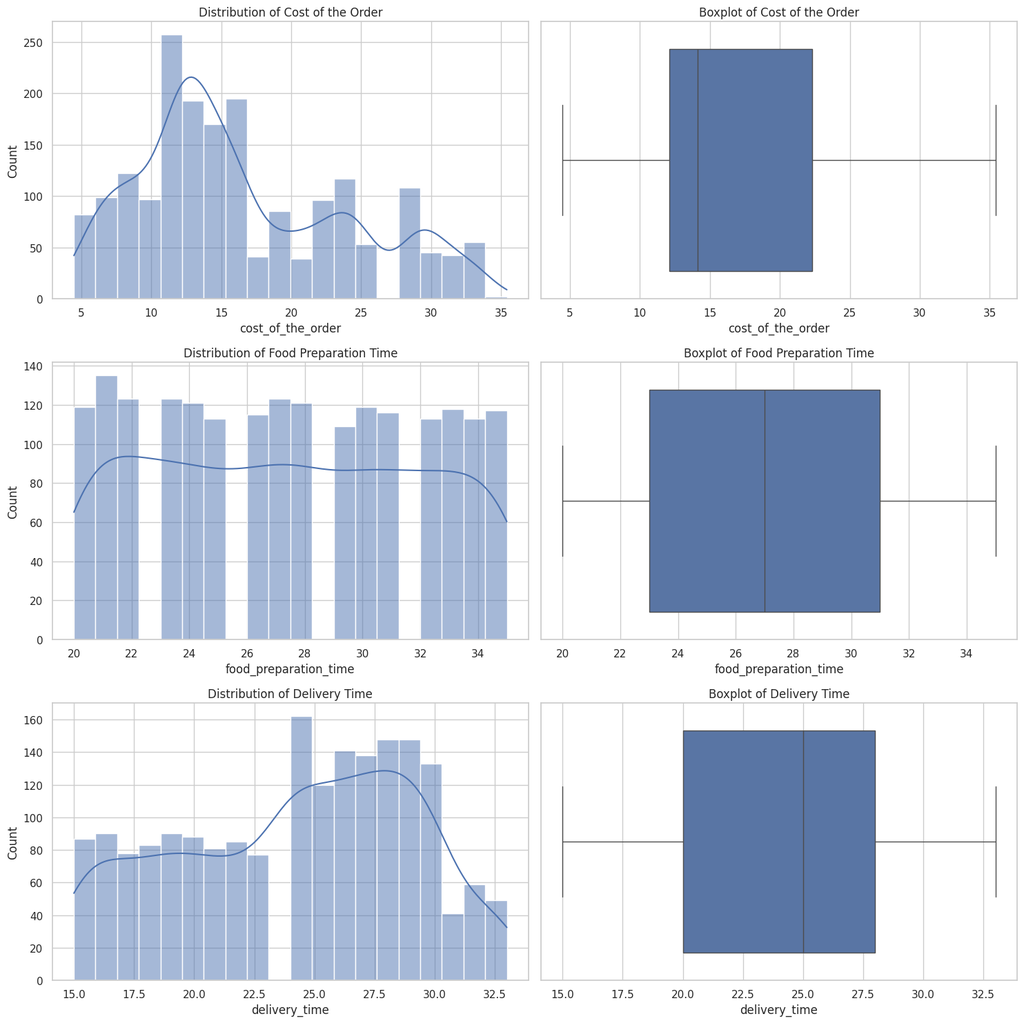

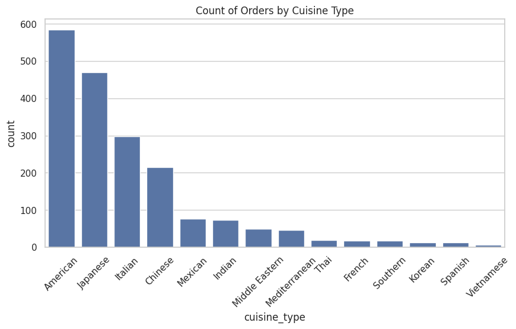

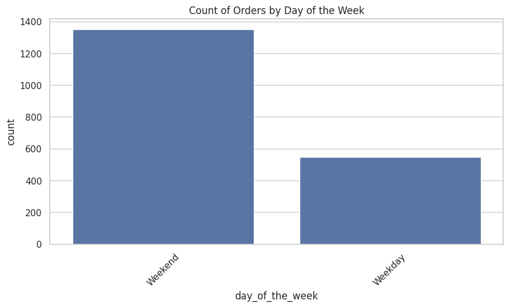

```python
# Write the code here
# Set the style for seaborn
sns.set(style="whitegrid")

# Create a figure with subplots for each variable
fig, axes = plt.subplots(3, 2, figsize=(15, 15))

# Histogram and Boxplot for 'cost_of_the_order'
sns.histplot(df['cost_of_the_order'], bins=20, kde=True, ax=axes[0, 0])
axes[0, 0].set_title('Distribution of Cost of the Order')
sns.boxplot(x=df['cost_of_the_order'], ax=axes[0, 1])
axes[0, 1].set_title('Boxplot of Cost of the Order')

# Histogram and Boxplot for 'food_preparation_time'
sns.histplot(df['food_preparation_time'], bins=20, kde=True, ax=axes[1, 0])
axes[1, 0].set_title('Distribution of Food Preparation Time')
sns.boxplot(x=df['food_preparation_time'], ax=axes[1, 1])
axes[1, 1].set_title('Boxplot of Food Preparation Time')

# Histogram and Boxplot for 'delivery_time'
sns.histplot(df['delivery_time'], bins=20, kde=True, ax=axes[2, 0])
axes[2, 0].set_title('Distribution of Delivery Time')
sns.boxplot(x=df['delivery_time'], ax=axes[2, 1])
axes[2, 1].set_title('Boxplot of Delivery Time')

# Adjust the layout
plt.tight_layout()

# Countplot for categorical variables
plt.figure(figsize=(10, 5))
sns.countplot(data=df, x='cuisine_type', order=df['cuisine_type'].value_counts().index)
plt.title('Count of Orders by Cuisine Type')
plt.xticks(rotation=45)
plt.show()

plt.figure(figsize=(10, 5))
sns.countplot(data=df, x='day_of_the_week', order=df['day_of_the_week'].value_counts().index)
plt.title('Count of Orders by Day of the Week')
plt.xticks(rotation=45)
plt.show()
```

### **Question 7**: Which are the top 5 restaurants in terms of the number of orders received?

```
Top 5 restaurants in terms of number of orders received:
               restaurant_name  num_orders
136                Shake Shack         219
153          The Meatball Shop         132
21           Blue Ribbon Sushi         119
20   Blue Ribbon Fried Chicken          96
109                       Parm          68
```

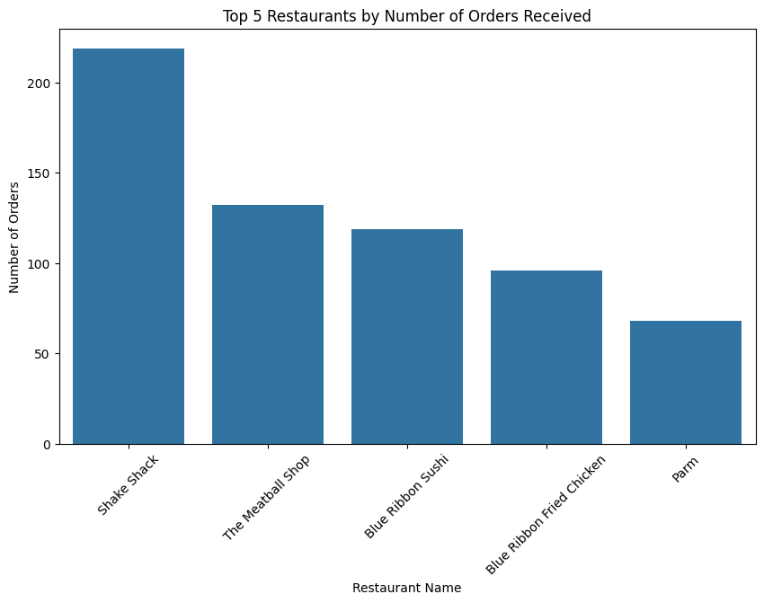

```python
# Write the code here

# Group by restaurant and count the number of orders
top_restaurants = df.groupby('restaurant_name')['order_id'].count().reset_index()

# Rename the columns for clarity
top_restaurants.columns = ['restaurant_name', 'num_orders']

# Sort the restaurants by the number of orders in descending order and get the top 5
top_5_restaurants = top_restaurants.sort_values(by='num_orders', ascending=False).head(5)

# Display the top 5 restaurants
print("Top 5 restaurants in terms of number of orders received:")
print(top_5_restaurants)

# Plot a bar chart for visualization
plt.figure(figsize=(10, 6))
sns.barplot(x='restaurant_name', y='num_orders', data=top_5_restaurants)
plt.title('Top 5 Restaurants by Number of Orders Received')
plt.xlabel('Restaurant Name')
plt.ylabel('Number of Orders')
plt.xticks(rotation=45)
plt.show()
```

#### Observations:

## - Top 1: Shake Shack has the most orders total is 219.

## - Top 2: The Meatball Shop has the second most orders total is 132.

## - Top 3: Blue Ribbon Sushi has the third most orders total is 119.

## - Top 4: Blue Ribbon Fried Chicken has the fourth most orders total is 96.

## - Top 5: Parm has the fifth most orders total is 68.

### **Question 8**: Which is the most popular cuisine on weekends?

```
cuisine_type
American          415
Japanese          335
Italian           207
Chinese           163
Mexican            53
Indian             49
Mediterranean      32
Middle Eastern     32
Thai               15
French             13
Korean             11
Southern           11
Spanish            11
Vietnamese          4
Name: count, dtype: int64
```

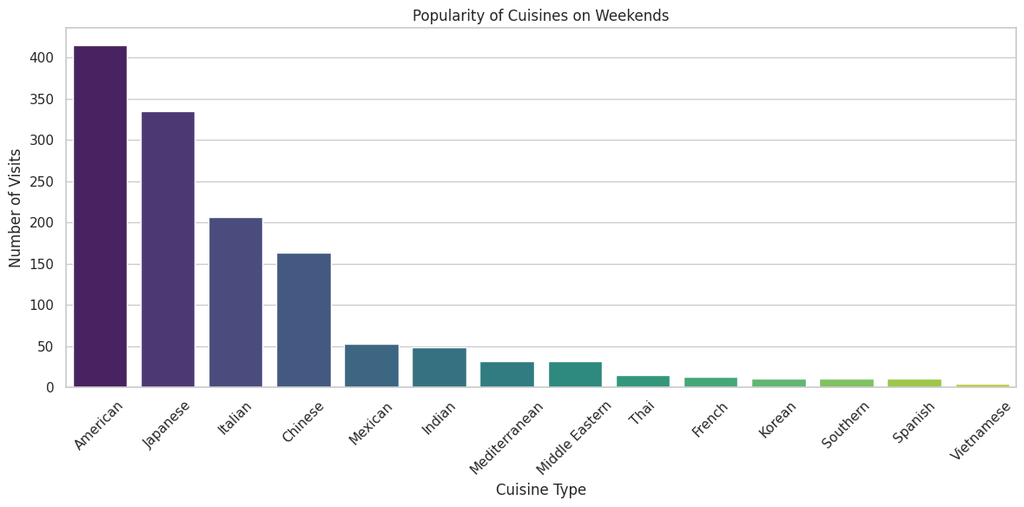

```python
# Write the code here
# Filter data for weekends (Saturday and Sunday)
weekend_data = df[df['day_of_the_week'].isin(['Weekend'])]

# Count the occurrences of each cuisine type on weekends
cuisine_counts = weekend_data['cuisine_type'].value_counts()

# Display the counts
print(cuisine_counts)

# Univariate Analysis: Visualize the distribution of cuisines
plt.figure(figsize=(12, 6))
sns.barplot(x=cuisine_counts.index, y=cuisine_counts.values, palette='viridis', legend=False)
plt.title('Popularity of Cuisines on Weekends')
plt.xlabel('Cuisine Type')
plt.ylabel('Number of Visits')
plt.xticks(rotation=45)
plt.tight_layout()
plt.show()

# Optional: Save the plot
plt.savefig('cuisine_popularity_weekends.png')
```

#### Observations:

## - American has the highest number of cuisine on weekends. (415)

## - Followed by Japanese(335) and Italian(207)

### **Question 9**: What percentage of the orders cost more than 20 dollars?

```
Percentage of orders costing more than $20: 29.24%
```

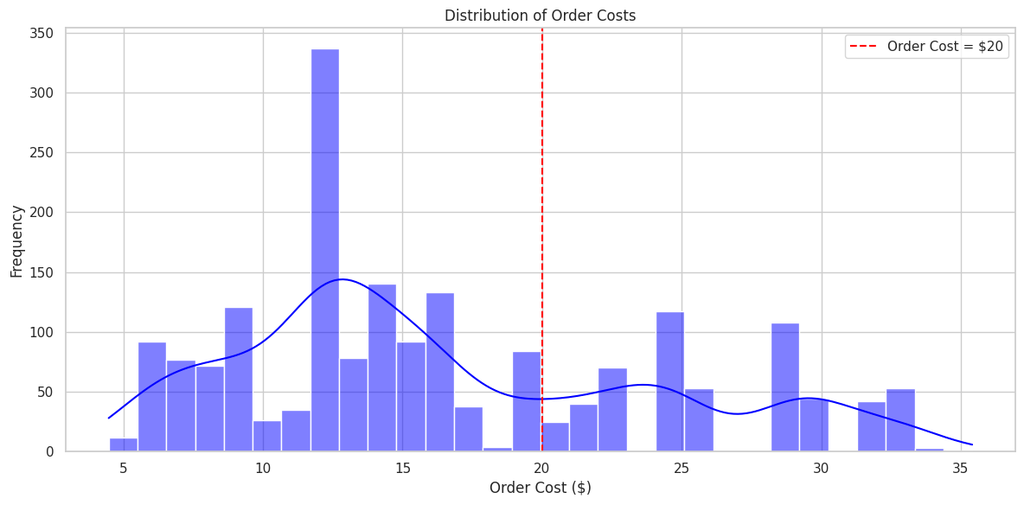

```python
# Write the code here
# Assuming 'df' is your DataFrame and it contains the column 'cost_of_the_order'
# Check if the 'cost_of_the_order' column exists
if 'cost_of_the_order' in df.columns:

    # Total number of orders
    total_orders = df.shape[0]

    # Number of orders costing more than $20
    orders_above_20 = df[df['cost_of_the_order'] > 20].shape[0]

    # Calculate percentage of orders costing more than $20
    if total_orders > 0:  # To avoid division by zero
        percentage_above_20 = (orders_above_20 / total_orders) * 100
        print(f"Percentage of orders costing more than $20: {percentage_above_20:.2f}%")
    else:
        print("No orders available in the dataset.")

    # Univariate Analysis: Visualize the distribution of order costs
    plt.figure(figsize=(12, 6))
    sns.histplot(df['cost_of_the_order'], bins=30, kde=True, color='blue')
    plt.axvline(x=20, color='red', linestyle='--', label='Order Cost = $20')
    plt.title('Distribution of Order Costs')
    plt.xlabel('Order Cost ($)')
    plt.ylabel('Frequency')
    plt.legend()
    plt.tight_layout()
    plt.show()

else:
    print("Column 'cost_of_the_order' does not exist in the DataFrame.")
```

## - Order Distribution: The majority of orders are clustered around the lower cost range, with a noticeable drop in frequency as the cost increases.

### **Question 10**: What is the mean order delivery time?

```
Mean Order Delivery Time: 24.16 units
```

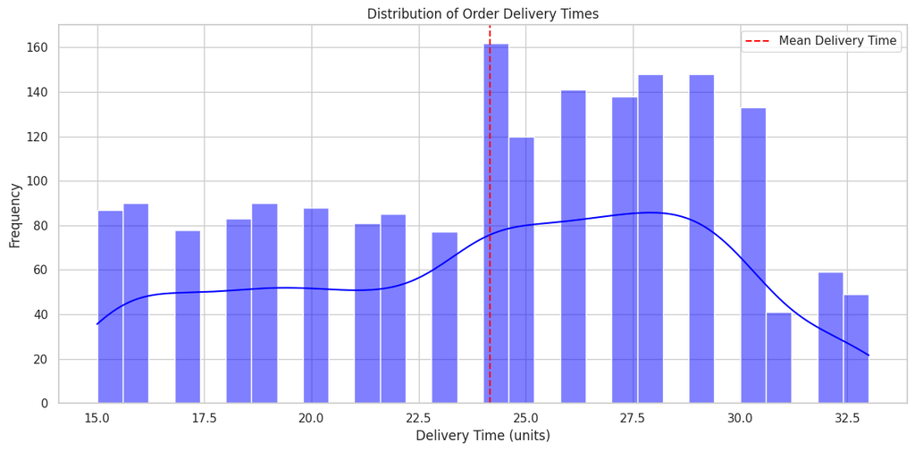

```python
# Write the code here
# Check if 'delivery_time' exists
if 'delivery_time' in df.columns:
    # Calculate the mean delivery time using NumPy
    mean_delivery_time = np.mean(df['delivery_time'])
    print(f"Mean Order Delivery Time: {mean_delivery_time:.2f} units")  # Adjust units as necessary

    # Univariate Analysis: Visualize the distribution of delivery times
    plt.figure(figsize=(12, 6))
    sns.histplot(df['delivery_time'], bins=30, kde=True, color='blue')
    plt.axvline(x=mean_delivery_time, color='red', linestyle='--', label='Mean Delivery Time')
    plt.title('Distribution of Order Delivery Times')
    plt.xlabel('Delivery Time (units)')  # Adjust units as necessary
    plt.ylabel('Frequency')
    plt.legend()
    plt.tight_layout()
    plt.show()

else:
    print("Column 'delivery_time' does not exist in the DataFrame.")
```

## - The smooth curve suggests the overall trend of delivery times, with a gradual increase toward the mean and then a decrease beyond it.

### **Question 11:** The company has decided to give 20% discount vouchers to the top 3 most frequent customers. Find the IDs of these customers and the number of orders they placed

```
Top 3 customers and their order counts:
     customer_id  Order_Count
116        52832           13
84         47440           10
333        83287            9
```

[figure not shown]

```
Descriptive Statistics for Customer Orders:
count    1200.000000
mean        1.581667
std         1.090560
min         1.000000
25%         1.000000
50%         1.000000
75%         2.000000
max        13.000000
Name: Order_Count, dtype: float64
```

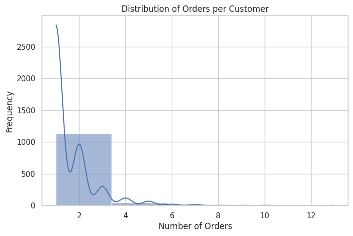

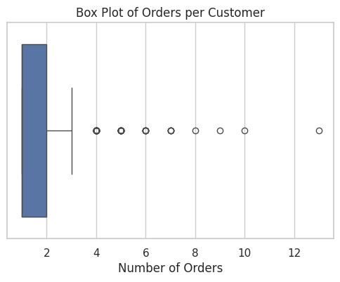

```python
# Write the code here
# Count orders for each customer
customer_order_count = df.groupby('customer_id').size().reset_index(name='Order_Count')

# Sort to get top 3 customers by order count
top_customers = customer_order_count.sort_values(by='Order_Count', ascending=False).head(3)

print("Top 3 customers and their order counts:")
print(top_customers)

# EDA - Plot Distribution of Orders per Customer
plt.figure(figsize=(10,6))
sns.barplot(x='customer_id', y='Order_Count', data=customer_order_count)
plt.title('Number of Orders Placed by Each Customer')
plt.xlabel('Customer ID')
plt.ylabel('Number of Orders')
plt.show()

# Univariate Analysis - Descriptive Statistics
print("Descriptive Statistics for Customer Orders:")
print(customer_order_count['Order_Count'].describe())

# Univariate Analysis - Histogram
plt.figure(figsize=(8,5))
sns.histplot(customer_order_count['Order_Count'], bins=5, kde=True)
plt.title('Distribution of Orders per Customer')
plt.xlabel('Number of Orders')
plt.ylabel('Frequency')
plt.show()

# Boxplot to identify spread and outliers
plt.figure(figsize=(6,4))
sns.boxplot(x=customer_order_count['Order_Count'])
plt.title('Box Plot of Orders per Customer')
plt.xlabel('Number of Orders')
plt.show()
```

#### Observations:

**Top 3 Most Frequent Customers:**

The top 3 customers based on their order counts are: Customer ID 52832 with 13 orders. Customer ID 47440 with 10 orders. Customer ID 83287 with 9 orders. These three customers will receive the 20% discount vouchers as they have placed the highest number of orders.

**Distribution of Orders:**

The mean number of orders per customer is approximately 1.58, with a standard deviation of 1.09. This suggests that most customers tend to place 1 or 2 orders, and a smaller number of customers place significantly more orders. The minimum number of orders is 1, while the maximum number of orders is 13, reflecting a wide range between customers who place just one order and those who place significantly more. Box Plot and Outliers:

**Concentration of Orders:**

The 25th percentile, 50th percentile (median), and 75th percentile all suggest that 1 to 2 orders are the most common, with a majority of customers placing just 1 order.

### Multivariate Analysis

### **Question 12**: Perform a multivariate analysis to explore relationships between the important variables in the dataset. (It is a good idea to explore relations between numerical variables as well as relations between numerical and categorical variables)

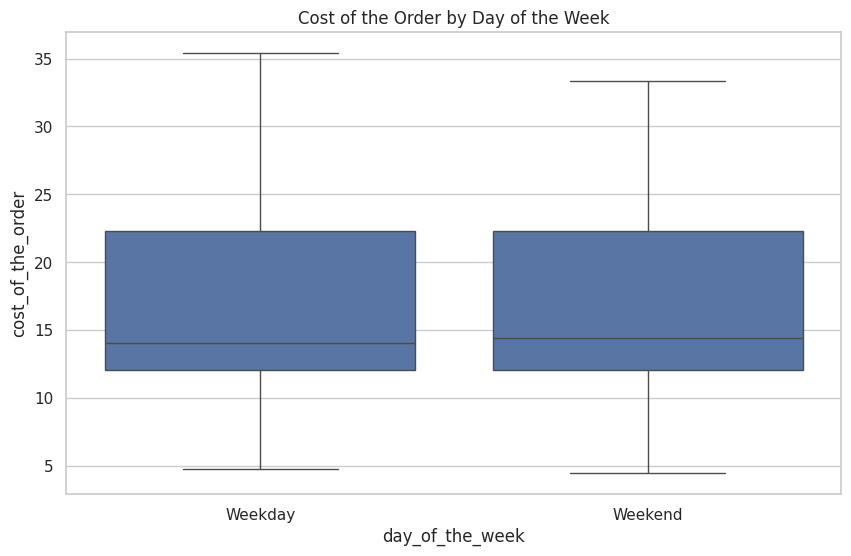

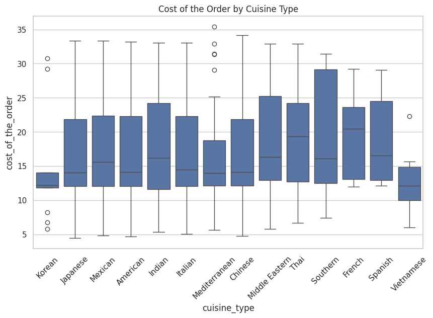

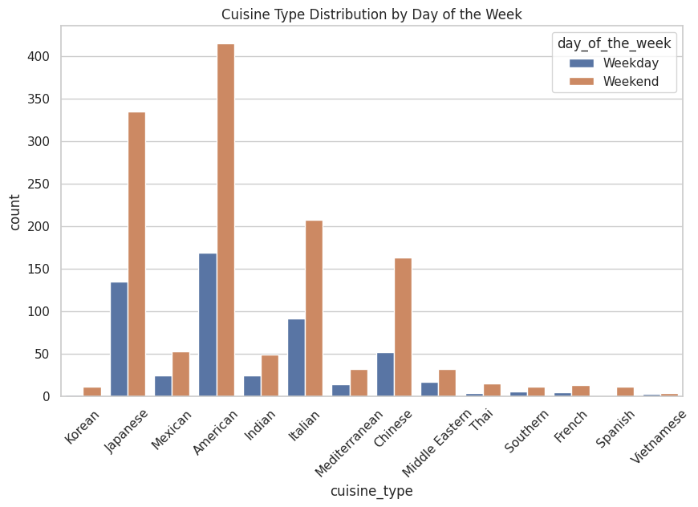

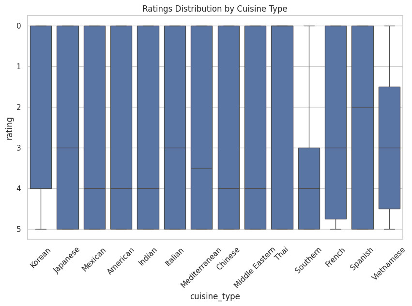

```python
# Convert day_of_the_week to categorical
df['day_of_the_week'] = df['day_of_the_week'].astype('category')

# Boxplot of cost_of_the_order by day_of_the_week
plt.figure(figsize=(10,6))
sns.boxplot(x='day_of_the_week', y='cost_of_the_order', data=df)
plt.title('Cost of the Order by Day of the Week')
plt.show()

# Boxplot of cost_of_the_order by cuisine_type
plt.figure(figsize=(10,6))
sns.boxplot(x='cuisine_type', y='cost_of_the_order', data=df)
plt.title('Cost of the Order by Cuisine Type')
plt.xticks(rotation=45)
plt.show()

# Countplot of cuisine_type by day_of_the_week
plt.figure(figsize=(10,6))
sns.countplot(x='cuisine_type', hue='day_of_the_week', data=df)
plt.title('Cuisine Type Distribution by Day of the Week')
plt.xticks(rotation=45)
plt.show()

# Boxplot of ratings by cuisine_type
plt.figure(figsize=(10,6))
sns.boxplot(x='cuisine_type', y='rating', data=df)
plt.title('Ratings Distribution by Cuisine Type')
plt.xticks(rotation=45)
plt.show()
```

### **Question 13:** The company wants to provide a promotional offer in the advertisement of the restaurants. The condition to get the offer is that the restaurants must have a rating count of more than 50 and the average rating should be greater than 4. Find the restaurants fulfilling the criteria to get the promotional offer

```
Restaurants eligible for the promotional offer:
Empty DataFrame
Columns: [restaurant_name, rating_count, avg_rating]
Index: []
```

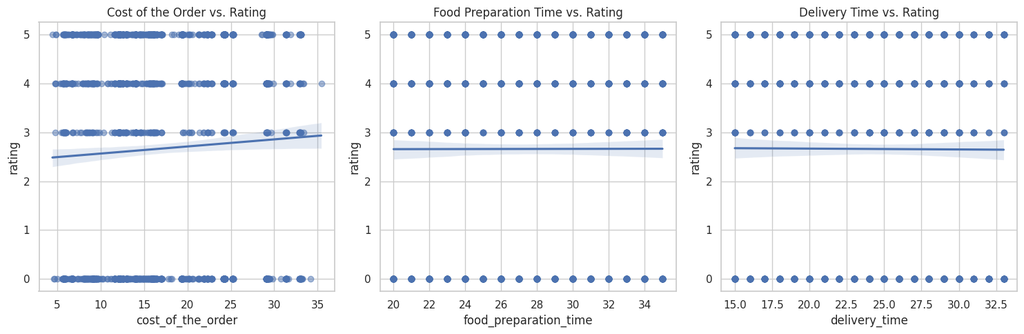

```
Correlation Matrix:
                       cost_of_the_order  food_preparation_time  \
cost_of_the_order               1.000000               0.041527
food_preparation_time           0.041527               1.000000
delivery_time                  -0.029949               0.011094
rating                          0.049531               0.001156

                       delivery_time    rating
cost_of_the_order          -0.029949  0.049531
food_preparation_time       0.011094  0.001156
delivery_time               1.000000 -0.003888
rating                     -0.003888  1.000000
```

```python
# Write the code here

# Convert 'rating' column to numeric (handle 'Not given')
df['rating'] = pd.to_numeric(df['rating'], errors='coerce')

# Group by restaurant and calculate the count and average of ratings
restaurant_stats = df.groupby('restaurant_name').agg(
    rating_count=('rating', 'count'),
    avg_rating=('rating', 'mean')
).reset_index()

# Filter restaurants with more than 50 ratings and an average rating > 4
promotional_restaurants = restaurant_stats[
    (restaurant_stats['rating_count'] > 50) & (restaurant_stats['avg_rating'] > 4)
]

# Display qualifying restaurants
print("Restaurants eligible for the promotional offer:")
print(promotional_restaurants)

# Step 2: Multivariate Analysis

# Filter out rows with missing ratings
valid_data = df.dropna(subset=['rating'])

# Set up the figure for multiple scatter plots with regression lines
plt.figure(figsize=(15, 5))

# Scatter plot for Cost of the Order vs. Rating
plt.subplot(1, 3, 1)
sns.regplot(x='cost_of_the_order', y='rating', data=valid_data, scatter_kws={'alpha':0.5})
plt.title('Cost of the Order vs. Rating')

# Scatter plot for Food Preparation Time vs. Rating
plt.subplot(1, 3, 2)
sns.regplot(x='food_preparation_time', y='rating', data=valid_data, scatter_kws={'alpha':0.5})
plt.title('Food Preparation Time vs. Rating')

# Scatter plot for Delivery Time vs. Rating
plt.subplot(1, 3, 3)
sns.regplot(x='delivery_time', y='rating', data=valid_data, scatter_kws={'alpha':0.5})
plt.title('Delivery Time vs. Rating')

plt.tight_layout()
plt.show()

# Correlation matrix
correlation_matrix = valid_data[['cost_of_the_order', 'food_preparation_time', 'delivery_time', 'rating']].corr()
print("Correlation Matrix:")
print(correlation_matrix)
```

#### Observations:

**Correlation Matrix Insights:** **Cost of the Order:** There is a very weak positive correlation with rating (0.049531), suggesting that higher costs might slightly increase ratings, but the relationship is not strong.

**Food Preparation Time:** Shows an almost negligible positive correlation with rating (0.001156), indicating that preparation time has little to no impact on customer ratings.

**Delivery Time:** Exhibits an extremely weak negative correlation with rating (-0.003888), implying that longer delivery times might slightly decrease ratings, but this effect is minimal.

### **Question 14:** The company charges the restaurant 25% on the orders having cost greater than 20 dollars and 15% on the orders having cost greater than 5 dollars. Find the net revenue generated by the company across all orders

```
Total Revenue Generated by the Company: $6166.30
```

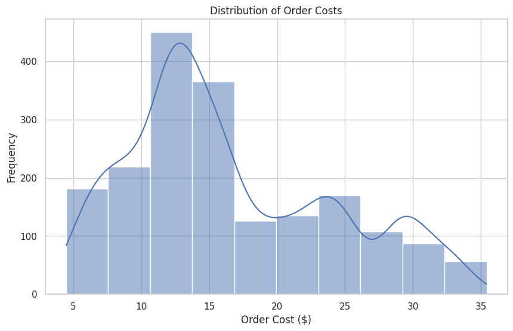

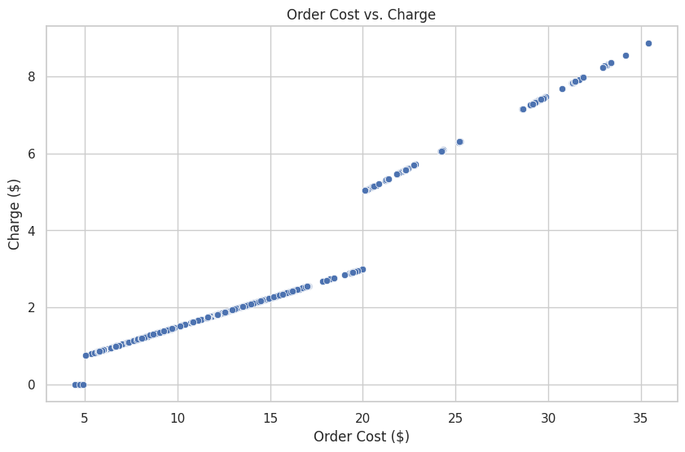

```
   rating  predicted_rating
0       0          2.871935
1       0          2.597695
2       5          2.595413
3       3          2.854720
4       4          2.589524
```

```python
# Write the code here
# Calculate charges
df['charge'] = df['cost_of_the_order'].apply(lambda x: 0.25 * x if x > 20 else (0.15 * x if x > 5 else 0))

# Calculate total revenue generated by the company
total_revenue = df['charge'].sum()
print(f"Total Revenue Generated by the Company: ${total_revenue:.2f}")

plt.figure(figsize=(10, 6))
sns.histplot(df['cost_of_the_order'], bins=10, kde=True)
plt.title('Distribution of Order Costs')
plt.xlabel('Order Cost ($)')
plt.ylabel('Frequency')
plt.show()

plt.figure(figsize=(10, 6))
sns.scatterplot(x='cost_of_the_order', y='charge', data=df)
plt.title('Order Cost vs. Charge')
plt.xlabel('Order Cost ($)')
plt.ylabel('Charge ($)')
plt.show()

from sklearn.linear_model import LinearRegression

# Prepare data
X = df[['cost_of_the_order', 'food_preparation_time', 'delivery_time']]
y = df['rating']

# Train model
model = LinearRegression()
model.fit(X, y)

# Predict and evaluate
y_pred = model.predict(X)
df['predicted_rating'] = y_pred
print(df[['rating', 'predicted_rating']].head())
```

#### Observations:

1. **Revenue Generation:**

Total Revenue: The company generated a total revenue of $6166.30 from the charges applied to the orders.

1. **Predicted Ratings:** The predicted ratings for the first few orders show a range of values around 2.5 to 2.9, which indicates that the model predicts moderate ratings for most orders.
2. **Visualizations:**

Distribution of Order Costs: The histogram shows the frequency distribution of order costs, indicating how often different cost ranges occur. The overlaid line graph (density plot) helps visualize the distribution’s shape and central tendency.

Order Cost vs. Charge: The scatter plot illustrates the relationship between the cost of the order and the charge applied. It shows that higher order costs result in higher charges, as expected from the applied conditions.

### **Question 15:** The company wants to analyze the total time required to deliver the food. What percentage of orders take more than 60 minutes to get delivered from the time the order is placed? (The food has to be prepared and then delivered)

```
Percentage of orders taking more than 60 minutes: 10.54%
```

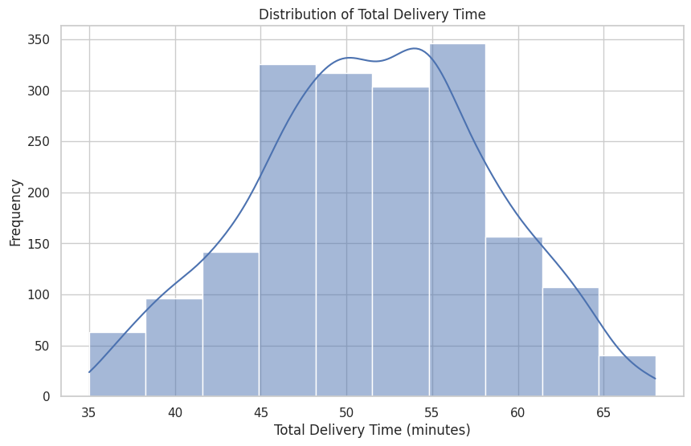

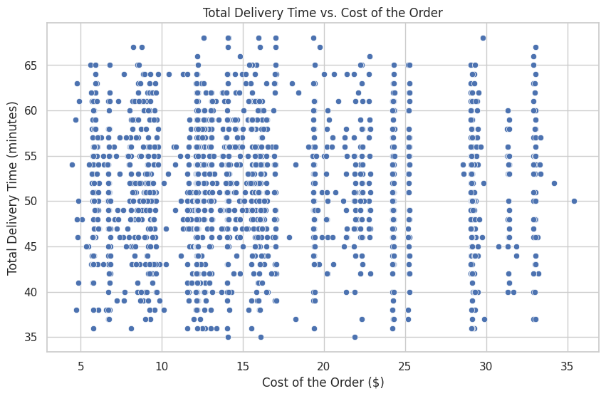

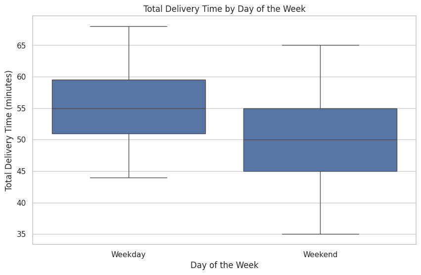

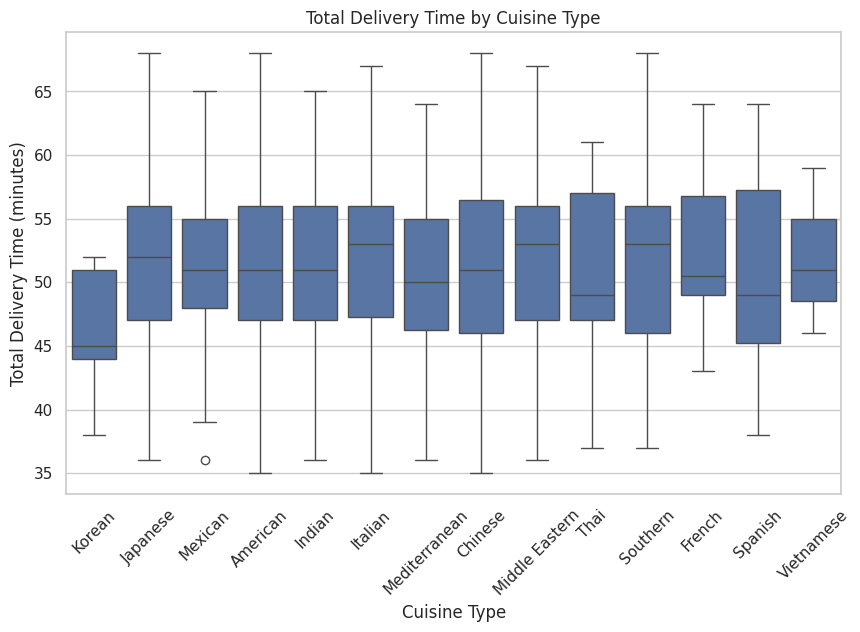

```python
# Write the code here

# Calculate total delivery time
df['total_delivery_time'] = df['food_preparation_time'] + df['delivery_time']

# Display the first few rows to verify the new column
df.head()

# Filter orders taking more than 60 minutes
orders_over_60 = df[df['total_delivery_time'] > 60]

# Calculate the percentage
percentage_over_60 = (len(orders_over_60) / len(df)) * 100
print(f"Percentage of orders taking more than 60 minutes: {percentage_over_60:.2f}%")

#Distribution of Total Delivery Time
plt.figure(figsize=(10, 6))
sns.histplot(df['total_delivery_time'], bins=10, kde=True)
plt.title('Distribution of Total Delivery Time')
plt.xlabel('Total Delivery Time (minutes)')
plt.ylabel('Frequency')
plt.show()

#Total Delivery Time vs. Cost of the Order
plt.figure(figsize=(10, 6))
sns.scatterplot(x='cost_of_the_order', y='total_delivery_time', data=df)
plt.title('Total Delivery Time vs. Cost of the Order')
plt.xlabel('Cost of the Order ($)')
plt.ylabel('Total Delivery Time (minutes)')
plt.show()

#Total Delivery Time by Day of the Week
plt.figure(figsize=(10, 6))
sns.boxplot(x='day_of_the_week', y='total_delivery_time', data=df)
plt.title('Total Delivery Time by Day of the Week')
plt.xlabel('Day of the Week')
plt.ylabel('Total Delivery Time (minutes)')
plt.show()

#Total Delivery Time by Cuisine Type
plt.figure(figsize=(10, 6))
sns.boxplot(x='cuisine_type', y='total_delivery_time', data=df)
plt.title('Total Delivery Time by Cuisine Type')
plt.xlabel('Cuisine Type')
plt.ylabel('Total Delivery Time (minutes)')
plt.xticks(rotation=45)
plt.show()
```

#### Observations:

The scatter plot shows the relationship between the cost of the order and the total delivery time. There is no clear pattern indicating that higher costs are associated with longer delivery times, suggesting that other factors might be influencing delivery times.

### **Question 16:** The company wants to analyze the delivery time of the orders on weekdays and weekends. How does the mean delivery time vary during weekdays and weekends?

```
Mean delivery time for weekdays and weekends:
 day_of_the_week
Weekday    28.340037
Weekend    22.470022
Name: delivery_time, dtype: float64
T-statistic: nan, P-value: nan
```

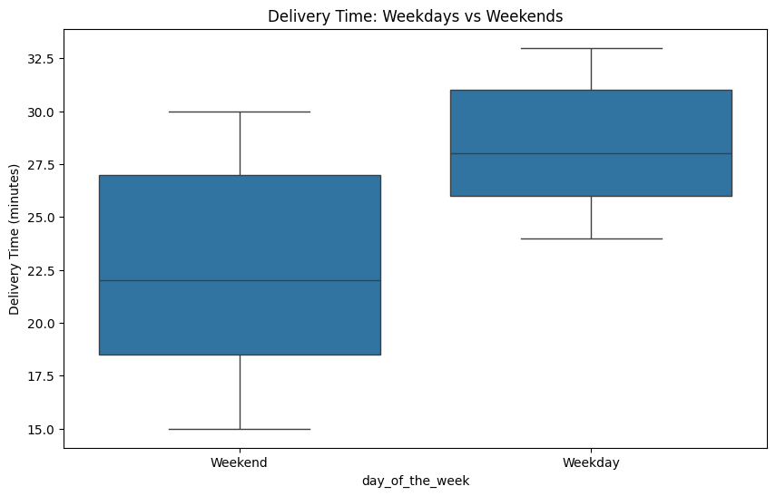

```python
# Write the code here

# Import necessary libraries
import pandas as pd
import seaborn as sns
import matplotlib.pyplot as plt
from scipy import stats

# Assuming the dataframe is already loaded into 'df'

# Calculate mean delivery time for 'weekday' and 'weekend'
mean_delivery_time = df.groupby('day_of_the_week')['delivery_time'].mean()
print("Mean delivery time for weekdays and weekends:\n", mean_delivery_time)

# Perform a t-test to compare the mean delivery time between weekdays and weekends
weekday_delivery = df[df['day_of_the_week'] == 'weekday']['delivery_time']
weekend_delivery = df[df['day_of_the_week'] == 'weekend']['delivery_time']

t_stat, p_value = stats.ttest_ind(weekday_delivery, weekend_delivery)
print(f"T-statistic: {t_stat}, P-value: {p_value}")

# Visualize the differences using boxplots
plt.figure(figsize=(10, 6))
sns.boxplot(x='day_of_the_week', y='delivery_time', data=df)
plt.title('Delivery Time: Weekdays vs Weekends')
plt.ylabel('Delivery Time (minutes)')
plt.show()
```

#### Observations:

**Mean Delivery Times:**

Weekdays: 28.34 minutes

Weekends: 22.47 minutes

This shows that, on average, delivery times are longer on weekdays compared to weekends, with a difference of approximately 5.87 minutes. Visualization (Boxplot):

The boxplot shows that the distribution of delivery times is wider for weekends compared to weekdays. The median delivery time for weekends is lower than weekdays, as seen by the position of the central line in the boxes. The spread of delivery times (interquartile range) is also larger on weekends, indicating more variability in delivery times during this period.

### Recommendations:

- Focus on High-Demand Cuisine Types: The business should prioritize and promote cuisine types that consistently generate high-value orders. If certain cuisines or restaurants are more profitable, targeted marketing campaigns could attract more customers in those categories. Leveraging seasonal trends in food preferences can also boost sales.
- Improve Underperforming Areas: For cuisine types or restaurants receiving lower feedback ratings, the business should focus on improving food quality, service, or delivery times. Offering targeted discounts to customers with low feedback scores can also help regain customer satisfaction and build loyalty.
- Invest in Customer Experience: Enhancing the overall customer experience, including improving delivery times and user-friendly app features, can help boost feedback ratings. Customers who receive timely, well-presented, and accurate orders are more likely to leave positive reviews and make repeat purchases.
- Introduce Feedback-Based Rewards: Encourage customers to leave feedback by offering incentives such as discounts on future orders. This can increase the volume of feedback, allowing the business to gather more data and further improve service based on customer input.

```python
!pip install nbconvert
```

```python
!jupyter nbconvert --to html /content/drive/MyDrive/Colab Notebooks/FDS_Project_LearnerNotebook_FullCode.ipynb
```

[output not shown]

[output cut: 134 more lines]

[output not shown]